## 0.1 Learning objectives

1. You familiar with the major visualization strategies for univariate, bivariate, and multivariate plots.
2. You can identify the appropriate plot(s) for visualizing discrete variables, continuous variables, and a combinations of both.
3. You can explain the names, functions, and types of variables used by each of the five named graphs (5NG) .

## 0.2 Five named graphs - the 5NG

In order to keep things simple in this chapter, we will cover some of the more basic `geom_` functions. We will primarily focus on five different types of graphics, each with a commonly given name. We term these “five named graphs” or in abbreviated form, the **5NG**:

1. scatterplots
2. linegraphs
3. histograms
4. boxplots
5. barplots

We’ll also present some variations of these plots, but with this basic repertoire of five graphics in your toolbox, you can visualize a wide array of different variable types. Note that certain plots are only appropriate for discrete variables, while others are only appropriate for continuous variables.

## 0.3 Univariate graphs

Univariate graphs plot the distribution of data from a single variable. The variable can be discrete (e.g., race, sex) or continuous (e.g., age, weight).

### 0.3.1 Discrete

The distribution of a single discrete variable is typically plotted with a **barplot**, or (less commonly) a pie chart.

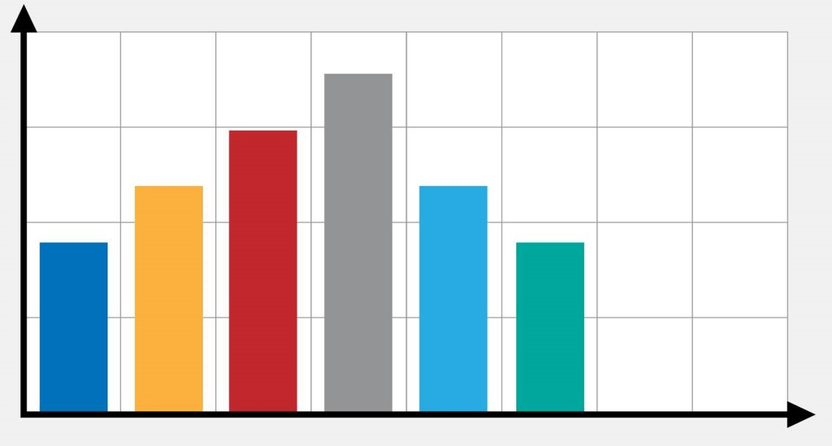

### 0.3.2 Continuous

The distribution of a single continuous variable is typically plotted with a **histogram** or a kernel density plot.

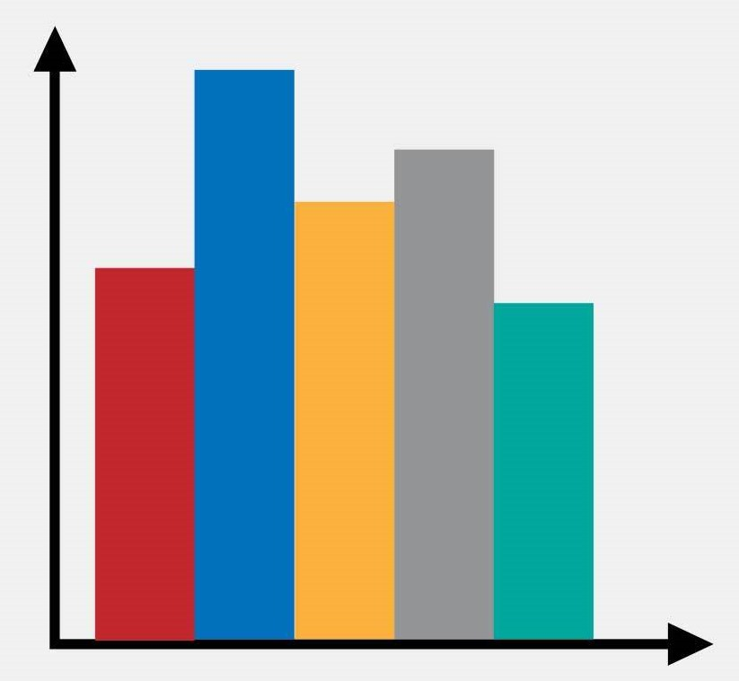

## 0.4 Bivariate graphs

Bivariate graphs display the relationship between two variables. The type of graph will depend on the measurement level of the variables (discrete or continuous).

### 0.4.1 Continuous vs. continuous

The relationship between two continuous variables is typically displayed using scatterplots and linegraphs.

The simplest display of two continuous variables is a **scatterplot**, with each variable represented on an axis.

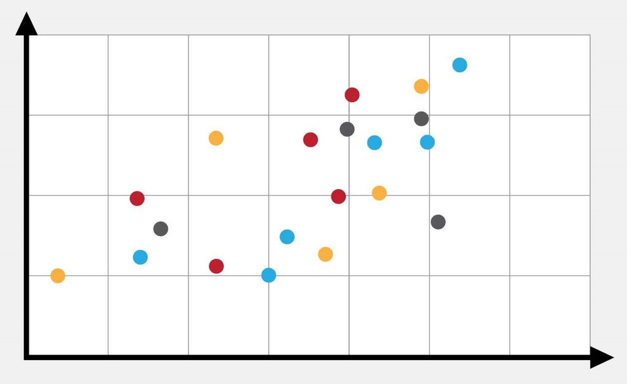

It is often useful to summarize the relationship displayed in the scatterplot using a best fit line. Many types of lines are supported, including linear, polynomial, and nonparametric (loess).

When one of the two variables represents time, a **linegraph** can be an effective method of displaying relationship.

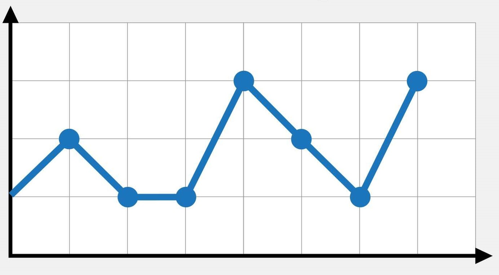

For example, we van use a linegraph to visualize time series data such as disease incidence per epidemic week.

### 0.4.2 Discrete vs. Continuous

When plotting the relationship between a discrete variable and a continuous variable, a large number of graph types are available. These include barplots, column charts, side-by-side boxplots, side-by-side violin plots, ridgeline plots, and more.

A side-by-side **boxplot** is very useful for comparing distributions of between groups of a continuous variable. The continuous variable is grouped by the levels of a discrete variable.

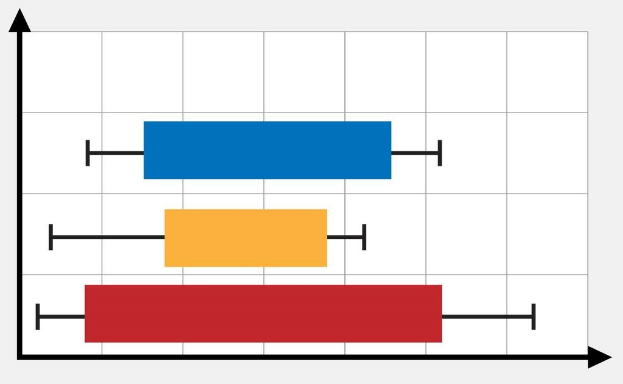

## 0.5 Multivariate Graphs

Multivariate graphs display the relationships among three or more variables. There are two common methods for accommodating multiple variables: grouping and faceting.

### 0.5.1 Grouping

In **grouping**, the values of the first two variables are mapped to the *x* and *y* axes. Then additional variables are mapped to other visual characteristics such as color, shape, size, line type, and transparency. Grouping allows you to plot the data for multiple groups in a single graph.

For example, the scatterplot illustration above, the color of the points could represent a third discrete variable. There are four different colors one for each level of the third variable.

### 0.5.2 Faceting

In **faceting**, a graph consists of several separate plots or *small multiples*, one for each level of a third variable

Grouping and faceting can turn bivariate graphs into multivariate graphs. Grouping allows you to plot multiple variables in a single graph, using visual characteristics such as color, shape, and size. When we facet graphs, we split a graph up into multiple plotting panels, where each panel contains a subset of the data.

## 0.6 5NG summary table

Let’s recap all five of the five named graphs (5NG) in a table summarizing their differences. Using these 5NG, you’ll be able to visualize the distributions and relationships of variables contained in a wide array of datasets. This will be even more the case as we start to map more variables to more of each `geom`etric object’s `aes`thetic attribute options, further unlocking the awesome power of the `ggplot2` package.

Summary of Five Named Graphs

|  | Name | Graph | Shows | `geom_*()` function | Notes |
| --- | --- | --- | --- | --- | --- |
| 1 | Scatterplot |  | Relationship between 2 continuous variables | `geom_point()` | A best fit line can summarize the relationship displayed in the scatterplot, using `geom_smooth()` |
| 2 | Linegraph |  | Relationship between 2 continuous variables | `geom_line()` | Used when there is a sequential order to x-variable (e.g., time) |
| 3 | Histogram |  | Distribution of 1 continuous variable | `geom_histogram()` | Facetted histograms show the distribution of 1 continuous variable split by the values of another discrete variable |
| 4 | Boxplot |  | Distribution of 1 continuous variable split by the values of a discrete variable | `geom_boxplot()` | Violin plots with `geom_violin()` allow for a more precise representation of the distribution |
| 5 | Barplot |  | Distribution of 1 discrete variable | `geom_bar()` or `geom_col()` | Stacked, side-by-side, and faceted barplots show the joint distribution of 2 discrete variables |

## 0.7 Additional resources

If you want to further unlock the power of the `ggplot2` package for data visualization, we suggest that you check out RStudio’s “Data Visualization with ggplot2” cheatsheet. This cheatsheet summarizes much more than what we’ve discussed in this chapter. In particular, it presents many more than the 5 `geom`etric objects we covered in this chapter while providing quick and easy to read visual descriptions. For all the `geom`etric objects, it also lists all the possible aesthetic attributes one can tweak. In the current version of RStudio in mid 2022, you can access this cheatsheet by going to the RStudio Menu Bar -> Help -> Cheatsheets -> “Data Visualization with ggplot2.” You can see a preview in the figure below. Alternatively, you can preview the cheat sheet by going to the ggplot2 Github page with this [link](https://github.com/rstudio/cheatsheets/blob/main/data-visualization-2.1.pdf).

[figure not shown]

## Contributors

The following team members contributed to this lesson:

- [JOY VAZ](https://thegraphcourses.org/members/joy)  
  R Developer and Instructor, The Graph Network

  Loves doing science and teaching science.
- [ADMIN TEAM](https://thegraphnetwork.training/members/admin/)  
  GRAPH Courses Administration Team

  The GRAPH Courses team is building epidemiological training courses to enhance disease surveillance and data science for public health across the globe.

## References

Some material in this lesson was adapted from the following sources:

- Ismay, Chester, and Albert Y. Kim. 2022. *A ModernDive into R and the Tidyverse*. https://moderndive.com/.
- Franke, Michael. 2021. *An Introduction to Data Analysis*. https://michael-franke.github.io/intro-data-analysis/.
- Kabacoff, Rob. 2020. *Data Visualization with R*. https://rkabacoff.github.io/datavis/.

This work is licensed under the [Creative Commons Attribution Share Alike](https://creativecommons.org/licenses/by-sa/4.0/) license.

[figure not shown]